# Prosper Loan Data Set Exploration by Shiu-Tang Li

#### 4.4 AmountDelinquent, DelinquenciesLast7Years, and loan status

This time I’m trying to use “AmountDelinquent” and “DelinquenciesLast7Years” varibles to predict good debt ratio, and I create a heat map. For both variables I’m breaking them into equal quantile groups, trying to balance the weight as much as I can. The color indicates good debt ratio.

But unfortunately it doesn’t work pretty well. The reader can find that the color fluctuates a lot. I would say on the buttom left corner the average good debt ratio is slightly higher, but other than that we can barely find other useful information.

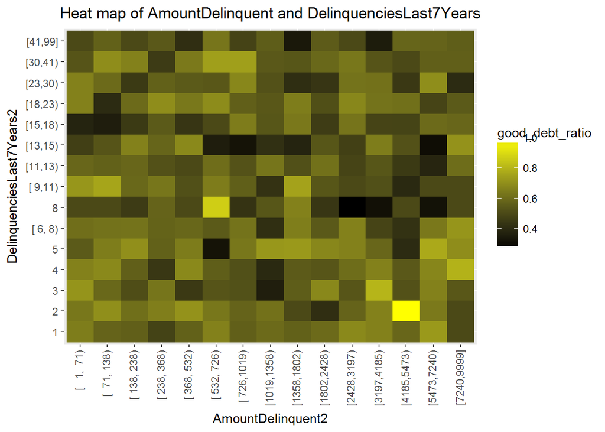

#### 4.5 Discussion

**4.5.1 Talk about some of the relationships you observed in this part of the investigation. Were there features that strengthened each other in terms of looking at your feature(s) of interest?

Say when I combined credit scores and prosper scores, I have a clearer picture about what good debts and bad debts look like.

**4.5.2 Were there any interesting or surprising interactions between features?

### 5. Final Plots

The three plots that reveals the most interesting information to the reader (in my opionion) are listed here.

### 5.1 a univariate plot

I would condsider giving higher priorities to those borrowers who’s term length is 12 months. Although there’re not many loan applicants having 12 months term length, it’s still a useful feature to help sort out good applicants.

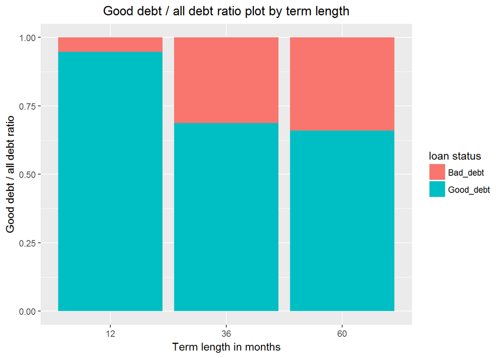

### 5.2 a bivariate plot

This plot distinguishes the loan status groups by examining borrow’s APR. This helps us to judge which group a loan record may belong to by checking the borrow’s APR.

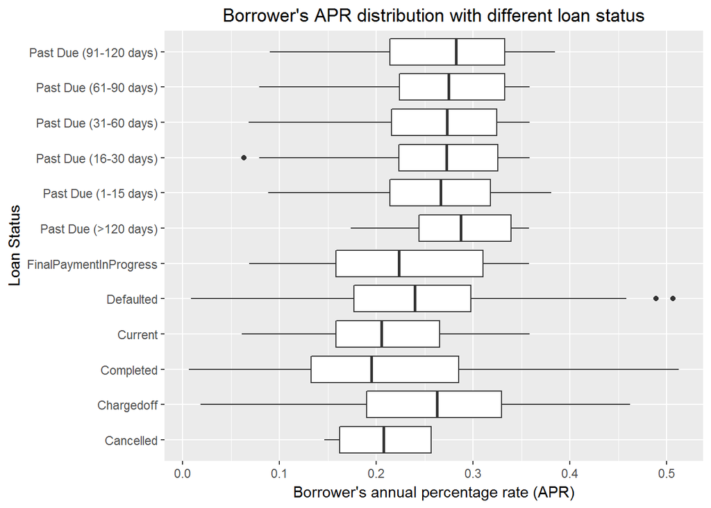

If we’d like to compare each group, we can run a t-test to see what’s going on. Say, “Completed” and “Chargedoff”:

```
##
##  Welch Two Sample t-test
##
## data:  x and y
## t = -56.997, df = 22155, p-value < 2.2e-16
## alternative hypothesis: true difference in means is not equal to 0
## 95 percent confidence interval:
##  -0.05065517 -0.04728701
## sample estimates:
## mean of x mean of y
## 0.2087811 0.2577522
```

With 95% confidence level, the APR of the “Completed” group is lower than the “Chargedoff” group by 4.73% to 5.07%.

### 5.3 a multivariate plot

I would wave good bye to those with low prosper score + low credit scores. It seems that the prosper score is doing a better job than credit scores, because those with low credit scores and high prosper scores still have a good debt ratio. Those with low prosper scores but high credit scores are the tricky ones. We need more information to decide whether the company should lend money to these guys. These guys may know how to cheat on the credit score system!

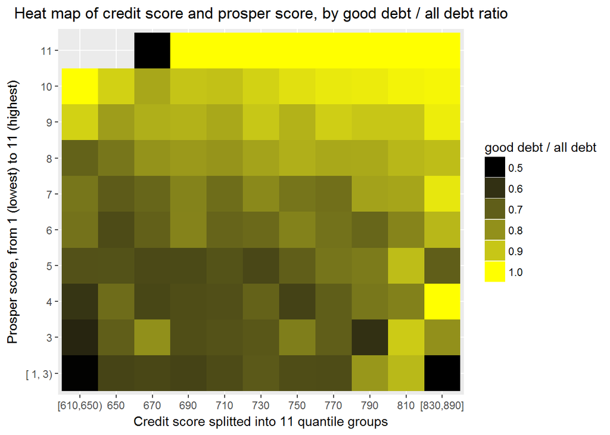

### 6. Reflection

#### Advantages and drawbacks

In this report I tried various plots to link a few variables to the loan status variable, and I did find some interesting connections.

But there’re still many possible relations which are not discovered, and for some of the connections I found I may not have chosen the best way to present the results. Also, I need think more carfully when later I try to put these thoughts together into a prediction model.

#### Technical limitations

When I use ggplot to create most of my plots, there’re some plots that I want to make but I still don’t know how to do it using ggplot. Say, I don’t know how to create a histogram and a frequency polygon on the same graph. Or, I don’t know how to create a bar plot, that for each x (discrete) values, it maps to two different feature values distinguished by colors. I don’t know questions like this can still be done with ggplot, or I have to use other tools.

#### What can be done next

If I have more time on this project, I would probably try if there’s any specific combinations of variables that give super high good debt ratio or bad debt ratios.

One thing I can think about now is that maybe we can design a way to detect cheaters. This can be done, say, by comparing the information of the occupations, monthly income, and loan purposes to see if it’s reasonable. Once we have a good cheater detection system, we can use it to analyze the good debt ratio of these “cheaters”.

Another thing I can think about is that all the above analysis is based on quantitative analysis. If we can somehow ask the borrower to provide a short statement on why they need to borrow money, and how they plan to return the money, maybe this type of qualitative analysis could help too, or may even do a better job than quantitative analysis.